# Ford GoBike Dataset Explanation

## Can PERÇİN

## Investigation Overview

Non-subscriber customers are travelling longer than subscribers in one trip. Can we prove it with data visualization?

Males are more likely to bike than females. Women tend not to choose memberships compared to men. Demonstration over a graph.

Top 10 Mostly used end and start point stations.

## Dataset Overview

In this project, data visualization which is the final chapter in Udacity Data Analysis Nanodegree course will be demonstrated by using different techniques such as Univariate, Bivariate, Multivariate.

Ford GoBike is a bike sharing system and "201902-fordgobike-tripdata" will be used as the master data table in this project. Wrangling and explorating this data is going to be shown systematically in this section. After completing the exploration part, a presentation will be shown by using the outputs of exploration part.

Data wrangling stages;

1. "start_time" and "End_time" have wrong data types.
2. "bike_id", "start_station_id" and "end_station_id" have wrong datatypes(float). These should be string.
3. "user_type", "gender" and "bike_share_for_all_trip" have wrong datatype(str). These should be categorical.
4. Age column should be created by considering birth dates.
5. There are some bike ride data that have higher than 70 years old and null values in member_age column. These should be dropped to prevent outliers in our visualizations. At the end we can convert "member_age" column's datatype into int64.
6. We should subdivide start_time into day,month and year columns.

## Relationship between Gender and Subscription

- Men have higher subscription rate than women according to the results of the pie chart above.
- If we consider the rate of genders for each category, Women tend not to choose memberships compared to men.

Female sub rate: 88.6%

Male sub rate: 91.2%

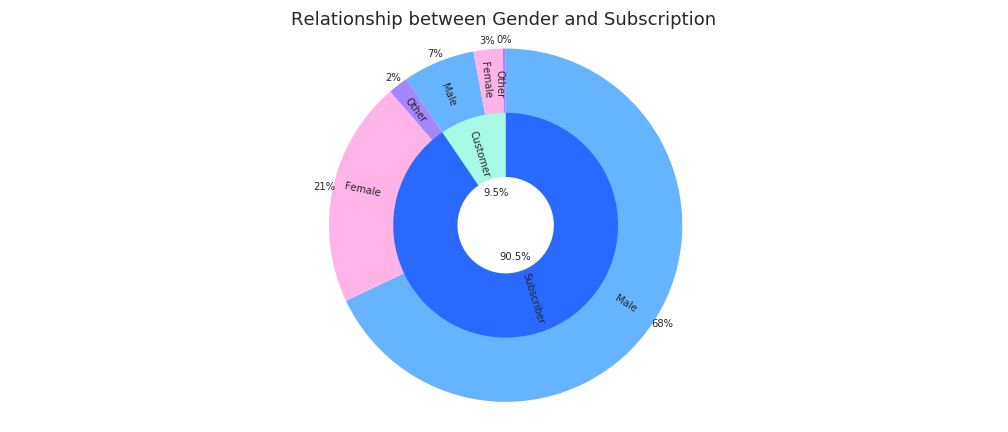

Non-subscribed customers travel more than subscribed customers. It was a previous finding which is still proven by our results.

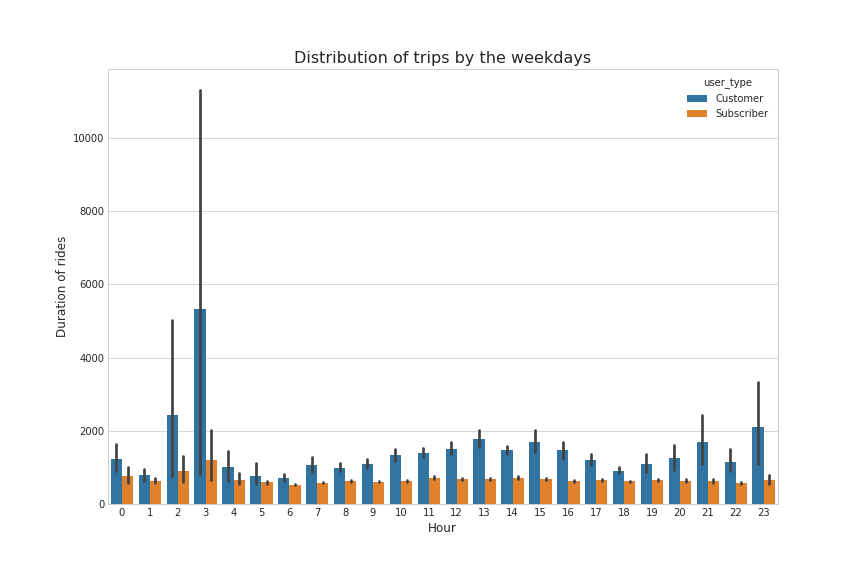

## Mostly Used Bike Trip Starting and Ending Stations

%13.6 of bike rides in top 10 start stations were at Market St at 10th St.

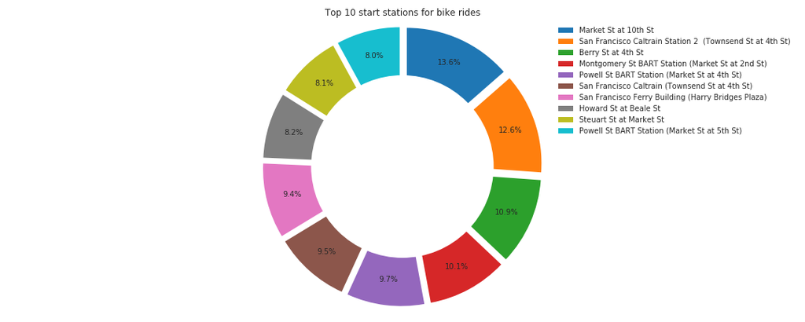

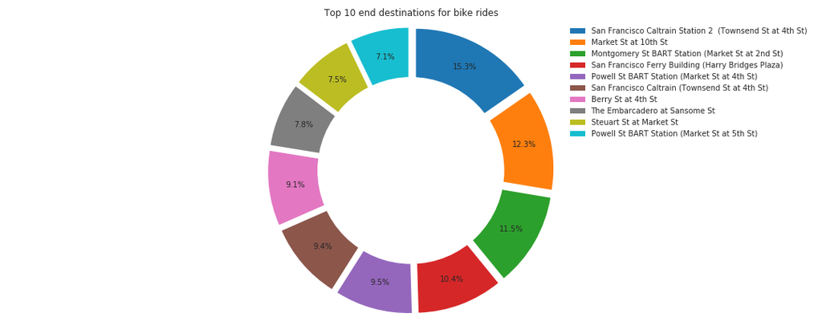

## Bike Trends

Young people prefer using bikes between 00:00 - 02:00 AM.

Female bike riders are younger than Male bike riders.

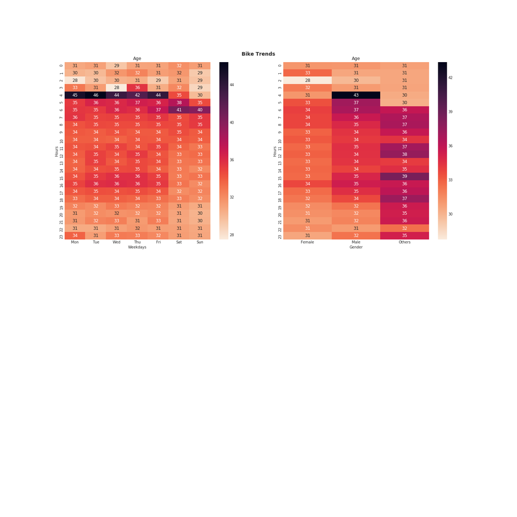